# 5 Social Network Analysis in R

From Networks to Insights

Author

Dr Clemens Jarnach

Published

March 18, 2026

## Setup and Essentials

### Loading packages

```r
library(igraph)
library(tidygraph)
library(ggraph)
library(tidyverse)
library(sna)
library(patchwork)
```

## Importing and Creating Networks

### Built-in network data

```r
data(flo)               ## Medici family network
flo
```

```
             Acciaiuoli Albizzi Barbadori Bischeri Castellani
Acciaiuoli            0       0         0        0          0
Albizzi               0       0         0        0          0
Barbadori             0       0         0        0          1
Bischeri              0       0         0        0          0
Castellani            0       0         1        0          0
Ginori                0       1         0        0          0
Guadagni              0       1         0        1          0
Lamberteschi          0       0         0        0          0
Medici                1       1         1        0          0
Pazzi                 0       0         0        0          0
Peruzzi               0       0         0        1          1
Pucci                 0       0         0        0          0
Ridolfi               0       0         0        0          0
Salviati              0       0         0        0          0
Strozzi               0       0         0        1          1
Tornabuoni            0       0         0        0          0
             Ginori Guadagni Lamberteschi Medici Pazzi Peruzzi
Acciaiuoli        0        0            0      1     0       0
Albizzi           1        1            0      1     0       0
Barbadori         0        0            0      1     0       0
Bischeri          0        1            0      0     0       1
Castellani        0        0            0      0     0       1
Ginori            0        0            0      0     0       0
Guadagni          0        0            1      0     0       0
Lamberteschi      0        1            0      0     0       0
Medici            0        0            0      0     0       0
Pazzi             0        0            0      0     0       0
Peruzzi           0        0            0      0     0       0
Pucci             0        0            0      0     0       0
Ridolfi           0        0            0      1     0       0
Salviati          0        0            0      1     1       0
Strozzi           0        0            0      0     0       1
Tornabuoni        0        1            0      1     0       0
             Pucci Ridolfi Salviati Strozzi Tornabuoni
Acciaiuoli       0       0        0       0          0
Albizzi          0       0        0       0          0
Barbadori        0       0        0       0          0
Bischeri         0       0        0       1          0
Castellani       0       0        0       1          0
Ginori           0       0        0       0          0
Guadagni         0       0        0       0          1
Lamberteschi     0       0        0       0          0
Medici           0       1        1       0          1
Pazzi            0       0        1       0          0
Peruzzi          0       0        0       1          0
Pucci            0       0        0       0          0
Ridolfi          0       0        0       1          1
Salviati         0       0        0       0          0
Strozzi          0       1        0       0          0
Tornabuoni       0       1        0       0          0
```

## Importing relational data

```r
# Read adjacency matrix
# relations <- read.csv("relationalData.csv", header = FALSE)
# relations <- as.matrix(relations)

# Read vertex attributes
# nodeInfo <- read.csv("vertexAttributes.csv", header = TRUE)

# Assign row/column names
# rownames(relations) <- nodeInfo$name
# colnames(relations) <- nodeInfo$name
```

## Creating network objects with igraph

The `igraph` package is now the standard for network analysis in R. It’s faster, more flexible, and better maintained than older packages.

```r
# From adjacency matrix
g_flo <- graph_from_adjacency_matrix(flo, mode = "undirected", weighted = NULL)

# Quick inspection
g_flo
```

```
IGRAPH 58e3b91 UN-- 16 20 --
+ attr: name (v/c)
+ edges from 58e3b91 (vertex names):
 [1] Acciaiuoli--Medici       Albizzi   --Ginori
 [3] Albizzi   --Guadagni     Albizzi   --Medici
 [5] Barbadori --Castellani   Barbadori --Medici
 [7] Bischeri  --Guadagni     Bischeri  --Peruzzi
 [9] Bischeri  --Strozzi      Castellani--Peruzzi
[11] Castellani--Strozzi      Guadagni  --Lamberteschi
[13] Guadagni  --Tornabuoni   Medici    --Ridolfi
[15] Medici    --Salviati     Medici    --Tornabuoni
+ ... omitted several edges
```

```r
# Create from edge list
edges <- tibble(
  from = c(1, 1, 2, 2, 3),
  to   = c(2, 3, 3, 4, 4)
)

g <- graph_from_data_frame(edges, directed = FALSE)
g
```

```
IGRAPH 73d7643 UN-- 4 5 --
+ attr: name (v/c)
+ edges from 73d7643 (vertex names):
[1] 1--2 1--3 2--3 2--4 3--4
```

## Inspecting igraph objects

Once we have an igraph object (i.e. a network) we can inspect it.

```r
# Printing the igraph object name returns descriptive information about the network
g_flo
```

```
IGRAPH 58e3b91 UN-- 16 20 --
+ attr: name (v/c)
+ edges from 58e3b91 (vertex names):
 [1] Acciaiuoli--Medici       Albizzi   --Ginori
 [3] Albizzi   --Guadagni     Albizzi   --Medici
 [5] Barbadori --Castellani   Barbadori --Medici
 [7] Bischeri  --Guadagni     Bischeri  --Peruzzi
 [9] Bischeri  --Strozzi      Castellani--Peruzzi
[11] Castellani--Strozzi      Guadagni  --Lamberteschi
[13] Guadagni  --Tornabuoni   Medici    --Ridolfi
[15] Medici    --Salviati     Medici    --Tornabuoni
+ ... omitted several edges
```

To examine vertex attributes:

```r
vertex_attr(g_flo)
```

```
$name
 [1] "Acciaiuoli"   "Albizzi"      "Barbadori"    "Bischeri"
 [5] "Castellani"   "Ginori"       "Guadagni"     "Lamberteschi"
 [9] "Medici"       "Pazzi"        "Peruzzi"      "Pucci"
[13] "Ridolfi"      "Salviati"     "Strozzi"      "Tornabuoni"
```

```r
# Name attribute
V(g_flo)$name
```

```
 [1] "Acciaiuoli"   "Albizzi"      "Barbadori"    "Bischeri"
 [5] "Castellani"   "Ginori"       "Guadagni"     "Lamberteschi"
 [9] "Medici"       "Pazzi"        "Peruzzi"      "Pucci"
[13] "Ridolfi"      "Salviati"     "Strozzi"      "Tornabuoni"
```

```r
# Degree attribute
V(g_flo)$degree
```

[output not shown]

We can add new attributes to vertices in the same way:

```r
V(g_flo)$fav_pizza <- rep(c("Margherita", "Pepperoni", "Vegetarian", "Hawaiian", "Quattro Formaggi"), times = 4)[1:16]
```

Edge attributes work identically. Access them with `E(igraph_name)$attribute_name`:

```r
# Add a new edge attribute
E(g_flo)$trust_level <- rep(c("high", "low", "medium", "high", "low"), times = 4)[1:20]

# View existing edge attributes
edge_attr(g_flo)
```

```
$trust_level
 [1] "high"   "low"    "medium" "high"   "low"    "high"   "low"
 [8] "medium" "high"   "low"    "high"   "low"    "medium" "high"
[15] "low"    "high"   "low"    "medium" "high"   "low"
```

```r
# Access a specific edge attribute
E(g_flo)$trust_level
```

```
 [1] "high"   "low"    "medium" "high"   "low"    "high"   "low"
 [8] "medium" "high"   "low"    "high"   "low"    "medium" "high"
[15] "low"    "high"   "low"    "medium" "high"   "low"
```

You can also query attributes conditionally. For example, to find vertices with degree greater than 2

```r
# 1. Create the attribute
V(g_flo)$degree <- igraph::degree(g_flo)

# 2. Now you can filter using the attribute
V(g_flo)[degree > 2]
```

```
+ 9/16 vertices, named, from 58e3b91:
[1] Albizzi    Bischeri   Castellani Guadagni   Medici
[6] Peruzzi    Ridolfi    Strozzi    Tornabuoni
```

## Network Description and Visualization

### Basic network properties

```r
vcount(g_flo)                  # number of vertices
```

```
[1] 16
```

```r
ecount(g_flo)                  # number of edges
```

```
[1] 20
```

```r
is_directed(g_flo)
```

```
[1] FALSE
```

```r
is_weighted(g_flo)
```

```
[1] FALSE
```

## Static visualisation

### Base igraph plotting

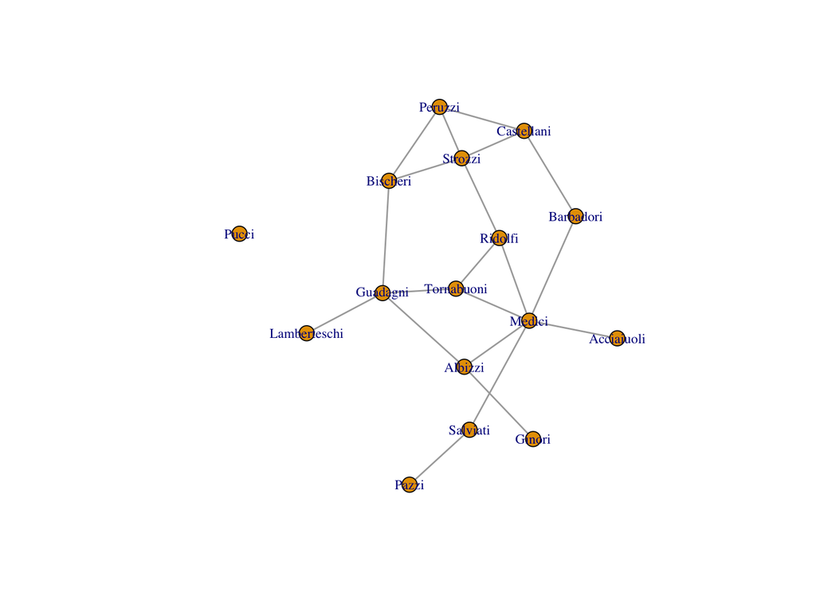

```r
plot(g_flo,
     vertex.size = 8,
     vertex.label.cex = 0.8,
     edge.width = 1.5)
```

### ggraph for publication-quality plots

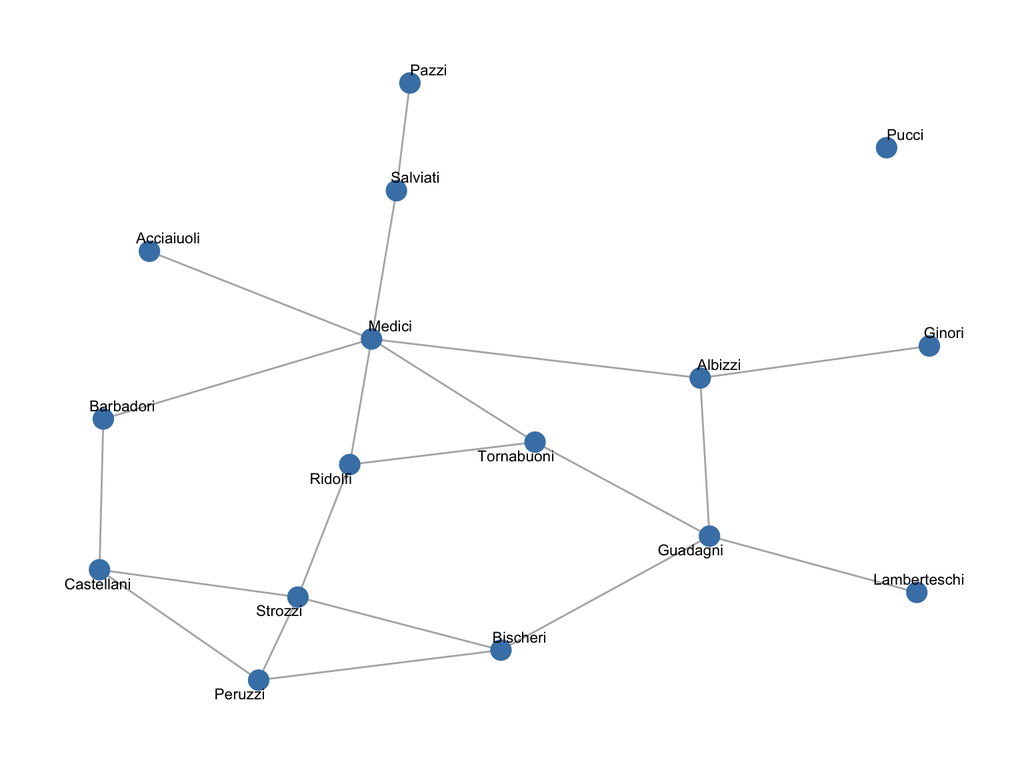

```r
ggraph(g_flo, layout = 'fr') +
  geom_edge_link(edge_width = 0.5, edge_colour = 'grey70') +
  geom_node_point(size = 5, colour = 'steelblue') +
  geom_node_text(aes(label = name), repel = TRUE, size = 3) +
  theme_graph()
```

## Working with Edges and Vertices

### Adding and removing edges

```r
g <- make_empty_graph(n = 5)

# Add edges by indexing
g <- g + edge(c(1, 2, 2, 3))
g
```

```
IGRAPH 00a22cd D--- 5 2 --
+ edges from 00a22cd:
[1] 1->2 2->3
```

### Vertex and edge attributes

```r
# Add vertex attributes
V(g_flo)$degree <- igraph::degree(g_flo)
V(g_flo)
```

```
+ 16/16 vertices, named, from 58e3b91:
 [1] Acciaiuoli   Albizzi      Barbadori    Bischeri
 [5] Castellani   Ginori       Guadagni     Lamberteschi
 [9] Medici       Pazzi        Peruzzi      Pucci
[13] Ridolfi      Salviati     Strozzi      Tornabuoni
```

```r
# Add edge attributes (on weighted example)
g_weighted <- g_flo
E(g_weighted)$weight <- runif(ecount(g_flo))
```

## Centrality Measures

### Degree centrality

Indicators of centrality assign numbers or rankings to nodes within a graph corresponding to their network position. Degree centrality is defined as the number of links incident upon a node (i.e., the number of ties that a node has).

```r
deg <- igraph::degree(g_flo)
deg
```

```
  Acciaiuoli      Albizzi    Barbadori     Bischeri   Castellani
           1            3            2            3            3
      Ginori     Guadagni Lamberteschi       Medici        Pazzi
           1            4            1            6            1
     Peruzzi        Pucci      Ridolfi     Salviati      Strozzi
           3            0            3            2            4
  Tornabuoni
           3
```

### Betweenness centrality

Betweenness centrality is a measure based on shortest paths in a graph. It measures how frequently a node appears on the shortest path between other nodes in the graph.

```r
bet <- igraph::betweenness(g_flo)
bet
```

```
  Acciaiuoli      Albizzi    Barbadori     Bischeri   Castellani
    0.000000    19.333333     8.500000     9.500000     5.000000
      Ginori     Guadagni Lamberteschi       Medici        Pazzi
    0.000000    23.166667     0.000000    47.500000     0.000000
     Peruzzi        Pucci      Ridolfi     Salviati      Strozzi
    2.000000     0.000000    10.333333    13.000000     9.333333
  Tornabuoni
    8.333333
```

### Closeness centrality

```r
clo <- igraph::closeness(g_flo)
clo
```

```
  Acciaiuoli      Albizzi    Barbadori     Bischeri   Castellani
  0.02631579   0.03448276   0.03125000   0.02857143   0.02777778
      Ginori     Guadagni Lamberteschi       Medici        Pazzi
  0.02380952   0.03333333   0.02325581   0.04000000   0.02040816
     Peruzzi        Pucci      Ridolfi     Salviati      Strozzi
  0.02631579          NaN   0.03571429   0.02777778   0.03125000
  Tornabuoni
  0.03448276
```

### Eigenvector centrality

Eigenvector centrality is a measure of the influence of a node in a network. It assigns relative scores to all nodes in the network based on the concept that connections to high-scoring nodes contribute more to the score of the node in question than equal connections to low-scoring nodes.

```r
eig <- igraph::eigen_centrality(g_flo)$vector
eig
```

```
  Acciaiuoli      Albizzi    Barbadori     Bischeri   Castellani
   0.3071155    0.5669336    0.4919853    0.6572037    0.6019551
      Ginori     Guadagni Lamberteschi       Medici        Pazzi
   0.1741141    0.6718805    0.2063449    1.0000000    0.1041427
     Peruzzi        Pucci      Ridolfi     Salviati      Strozzi
   0.6407743    0.0000000    0.7937398    0.3390994    0.8272688
  Tornabuoni
   0.7572302
```

### Visualising centrality

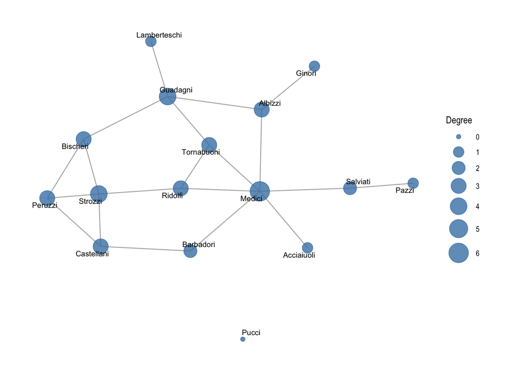

```r
ggraph(g_flo, layout = 'fr') +
  geom_edge_link(edge_width = 0.5, edge_colour = 'grey70') +
  geom_node_point(aes(size = deg), colour = 'steelblue', alpha = 0.8) +
  geom_node_text(aes(label = name), repel = TRUE, size = 3) +
  scale_size(range = c(2, 10)) +
  theme_graph() +
  labs(size = "Degree")
```

### Visualising centrality

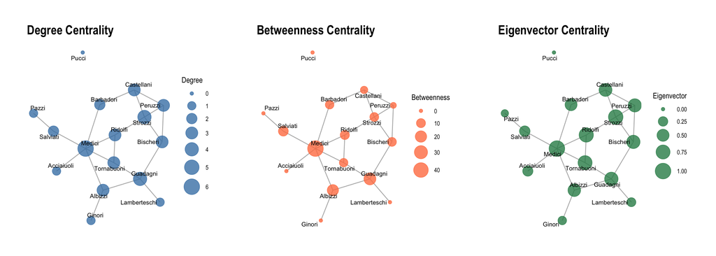

```r
# Calculate centrality measures
V(g_flo)$degree <- igraph::degree(g_flo)
V(g_flo)$betweenness <- igraph::betweenness(g_flo)
V(g_flo)$eigenvector <- igraph::eigen_centrality(g_flo)$vector

# Create a common layout for consistency across plots
layout_fr <- layout_with_fr(g_flo)

p1 <- ggraph(g_flo, layout = layout_fr) +
  geom_edge_link(edge_width = 0.5, edge_colour = 'grey70') +
  geom_node_point(aes(size = degree), colour = 'steelblue', alpha = 0.8) +
  geom_node_text(aes(label = name), repel = TRUE, size = 3) +
  scale_size(range = c(2, 10)) +
  theme_graph() +
  labs(title = "Degree Centrality", size = "Degree")

p2 <- ggraph(g_flo, layout = layout_fr) +
  geom_edge_link(edge_width = 0.5, edge_colour = 'grey70') +
  geom_node_point(aes(size = betweenness), colour = 'coral', alpha = 0.8) +
  geom_node_text(aes(label = name), repel = TRUE, size = 3) +
  scale_size(range = c(2, 10)) +
  theme_graph() +
  labs(title = "Betweenness Centrality", size = "Betweenness")

p3 <- ggraph(g_flo, layout = layout_fr) +
  geom_edge_link(edge_width = 0.5, edge_colour = 'grey70') +
  geom_node_point(aes(size = eigenvector), colour = 'seagreen', alpha = 0.8) +
  geom_node_text(aes(label = name), repel = TRUE, size = 3) +
  scale_size(range = c(2, 10)) +
  theme_graph() +
  labs(title = "Eigenvector Centrality", size = "Eigenvector")

(p1 | p2 | p3)
```

## Network-Level Indices

### Density and clustering

**Edge density** measures what proportion of all possible connections actually exist in the network. A value of 1 means the network is complete (everyone connected to everyone); 0 means no edges at all. For the Florentine families, this tells us how tightly knit the merchant elite were.

**Transitivity** (the global clustering coefficient) captures the tendency for triangles to form: if A is connected to B and B to C, how likely is it that A connects directly to C? Values range from 0 to 1, where higher values indicate more clustering. This is often interpreted as evidence of in-group cohesion or information flow redundancy in the network.

```r
edge_density(g_flo)
```

```
[1] 0.1666667
```

```r
transitivity(g_flo)              # global clustering coefficient
```

```
[1] 0.1914894
```

In this example, an edge density of 0.167 means only about one in six possible connections exist—the merchant elite were far from fully interconnected. In social networks, resource constraints (time, trust, capital) limit how many relationships any actor can maintain.

The transitivity of 0.191 is notably similar to the edge density, which suggests the network lacks strong clustering. If the families formed tight cliques—say, through repeated intermarriage within regional or trade blocs—we’d expect transitivity to substantially exceed density.

### Reciprocity

```r
# Create a directed example
g_dir <- graph_from_data_frame(
  tibble(from = c(1, 2, 2, 3), to = c(2, 1, 3, 2)),
  directed = TRUE
)

reciprocity(g_dir)
```

```
[1] 1
```

### Components and connectivity

```r
igraph::components(g_flo)
```

```
$membership
  Acciaiuoli      Albizzi    Barbadori     Bischeri   Castellani
           1            1            1            1            1
      Ginori     Guadagni Lamberteschi       Medici        Pazzi
           1            1            1            1            1
     Peruzzi        Pucci      Ridolfi     Salviati      Strozzi
           1            2            1            1            1
  Tornabuoni
           1

$csize
[1] 15  1

$no
[1] 2
```

```r
is_connected(g_flo)
```

```
[1] FALSE
```

A **component** is a maximal subset of vertices where every node can reach every other node through some path. `components()` returns the number of components and their sizes. If `is_connected()` returns TRUE, the network has a single component; otherwise, it’s fragmented into disconnected subgroups. For the Florentine families, this reveals whether the entire merchant elite formed one integrated social system or split into separate factions with no bridges between them.

```r
## Geodesic distances

distances(g_flo)[1:3, 1:3]
```

```
           Acciaiuoli Albizzi Barbadori
Acciaiuoli          0       2         2
Albizzi             2       0         2
Barbadori           2       2         0
```

```r
diameter(g_flo)
```

```
[1] 5
```

**Geodesic distance** is the shortest path length between two nodes. The distance matrix shows pairwise distances; the **diameter** is the longest shortest path in the network—the maximum “steps” needed to reach one node from any other. A small diameter indicates efficient information or resource flow across the network; a large diameter suggests bottlenecks or structural holes. For these families, diameter tells us whether influence could spread quickly through intermarriage chains or whether some families were isolated from broader networks.

## Subgroups and Cohesion

### k-cores

```r
kc <- coreness(g_flo)
kc
```

```
  Acciaiuoli      Albizzi    Barbadori     Bischeri   Castellani
           1            2            2            2            2
      Ginori     Guadagni Lamberteschi       Medici        Pazzi
           1            2            1            2            1
     Peruzzi        Pucci      Ridolfi     Salviati      Strozzi
           2            0            2            1            2
  Tornabuoni
           2
```

A **k-core** is a maximal subgraph where every node has degree at least k within that subgraph. `coreness()` assigns each vertex its core number—the highest k for which it belongs to a k-core. Core numbers reveal the “nested” structure of a network: high-coreness nodes form a densely connected inner circle, while low-coreness nodes sit on the periphery. For the Florentine families, this identifies the most influential merchant families (high coreness) who maintained tight reciprocal ties, versus those with fewer connections.

### Cliques

```r
cliques(g_flo, min = 3)
```

```
[[1]]
+ 3/16 vertices, named, from 58e3b91:
[1] Medici     Ridolfi    Tornabuoni

[[2]]
+ 3/16 vertices, named, from 58e3b91:
[1] Castellani Peruzzi    Strozzi

[[3]]
+ 3/16 vertices, named, from 58e3b91:
[1] Bischeri Peruzzi  Strozzi
```

A **clique** is a subset of vertices where every pair is connected; i.e. a complete subgraph. `cliques(g_flo, min = 3)` finds all groups of three or more families where all members are mutually connected. Cliques represent the tightest cohesive structures in the network and often indicate shared interests or formal alliances. However, cliques can overlap substantially, so they capture local cohesion rather than global community structure.

### Communities

```r
comm <- cluster_louvain(g_flo) # modularity-based communities
membership(comm)
```

```
  Acciaiuoli      Albizzi    Barbadori     Bischeri   Castellani
           1            2            3            3            3
      Ginori     Guadagni Lamberteschi       Medici        Pazzi
           2            2            2            1            1
     Peruzzi        Pucci      Ridolfi     Salviati      Strozzi
           3            4            1            1            3
  Tornabuoni
           1
```

```r
modularity(comm)
```

```
[1] 0.39875
```

**Communities** are groups of vertices that are more densely connected internally than to the rest of the network. The Louvain algorithm optimises **modularity**—a measure of how well the partition maximises within-group edges relative to between-group edges. `membership(comm)` assigns each vertex to a community; `modularity(comm)` returns a score from 0 to 1, where higher values indicate stronger community structure. Unlike cliques, communities partition the entire network into non-overlapping groups, offering a global view of the network’s factional organisation.

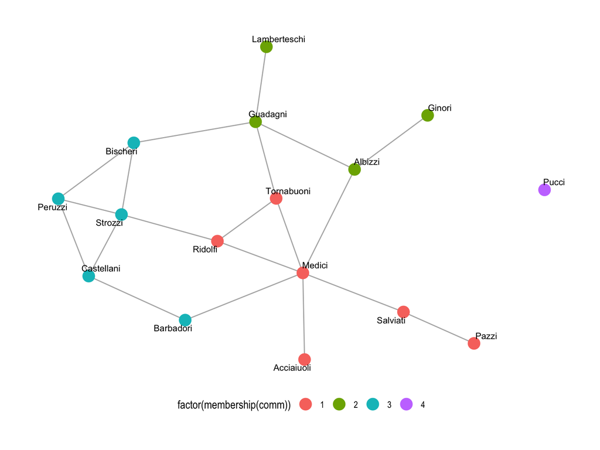

```r
ggraph(g_flo, layout = 'fr') +
  geom_edge_link(edge_width = 0.5, edge_colour = 'grey70') +
  geom_node_point(aes(colour = factor(membership(comm))), size = 5) +
  geom_node_text(aes(label = name), repel = TRUE, size = 3) +
  theme_graph() +
  theme(legend.position = 'bottom')
```

## Structural Equivalence

Two people are structurally equivalent if they have the exact same connections to the same people, even if they don’t know each other directly. Put simply, it is trying to identify “who plays the same role” in a network.

We use `method = "invlogweight"`, which is a Inverse Log-Weight to weight connections. It suggests that sharing a connection with a “popular” person (a hub) is less telling than sharing a connection with a “lonely” person. If you and I both know the same person who has 100 friends, it might be a coincidence; if we both know the same person who only has one friend, we are likely very similar in the social structure.

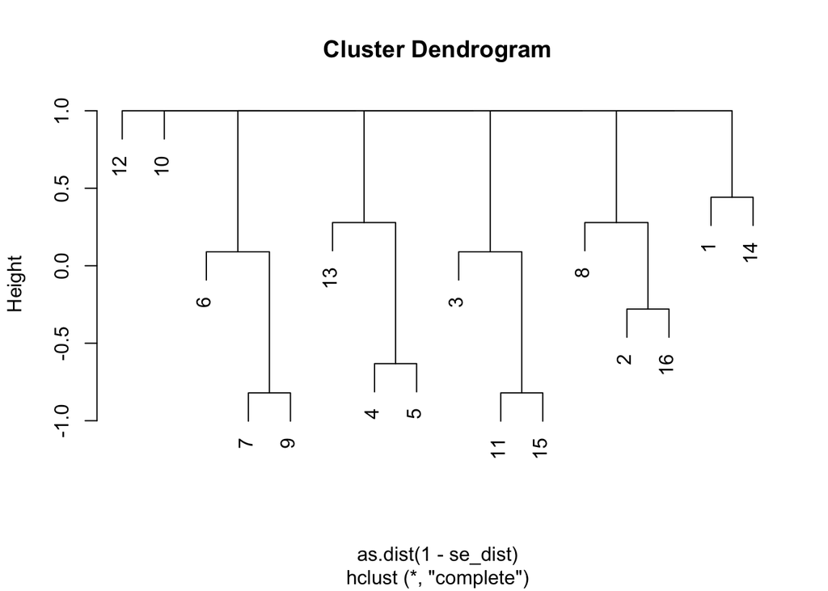

```r
##  Correlation of profiles
se_dist <- similarity(g_flo, method = "invlogweight")

##  Hierarchical clustering
hc <- hclust(as.dist(1 - se_dist))
plot(hc)
```

Nodes that are joined together at the very bottom of the tree are the most “structurally equivalent.” As you move up the tree, the groups become broader and less similar.

```r
# Create Index-Name data frame
flo_families <- data.frame(
  Index = 1:vcount(g_flo),
  Name = V(g_flo)$name
)

# View the table
print(flo_families)
```

```
   Index         Name
1      1   Acciaiuoli
2      2      Albizzi
3      3    Barbadori
4      4     Bischeri
5      5   Castellani
6      6       Ginori
7      7     Guadagni
8      8 Lamberteschi
9      9       Medici
10    10        Pazzi
11    11      Peruzzi
12    12        Pucci
13    13      Ridolfi
14    14     Salviati
15    15      Strozzi
16    16   Tornabuoni
```

## Random Graph Models

### Erdős–Rényi

Each possible edge is included independently with probability p. Produces a network with roughly uniform randomness and low clustering.

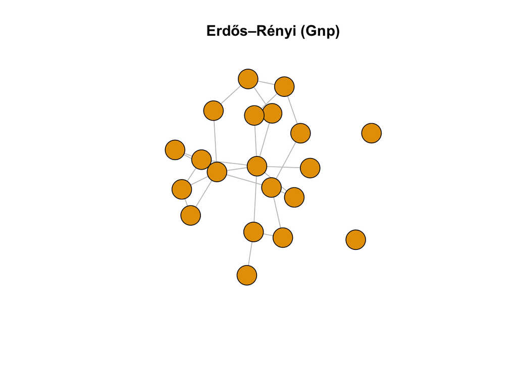

```r
g_er <- sample_gnp(n = 20, p = 0.15)

plot(g_er, main = "Erdős–Rényi (Gnp)", vertex.size = 20, vertex.label = NA, edge.color = "gray")
```

### Configuration model (fixed degree sequence)

Generates a random graph that preserves a specified degree sequence. Useful to test network properties while controlling for node degrees.

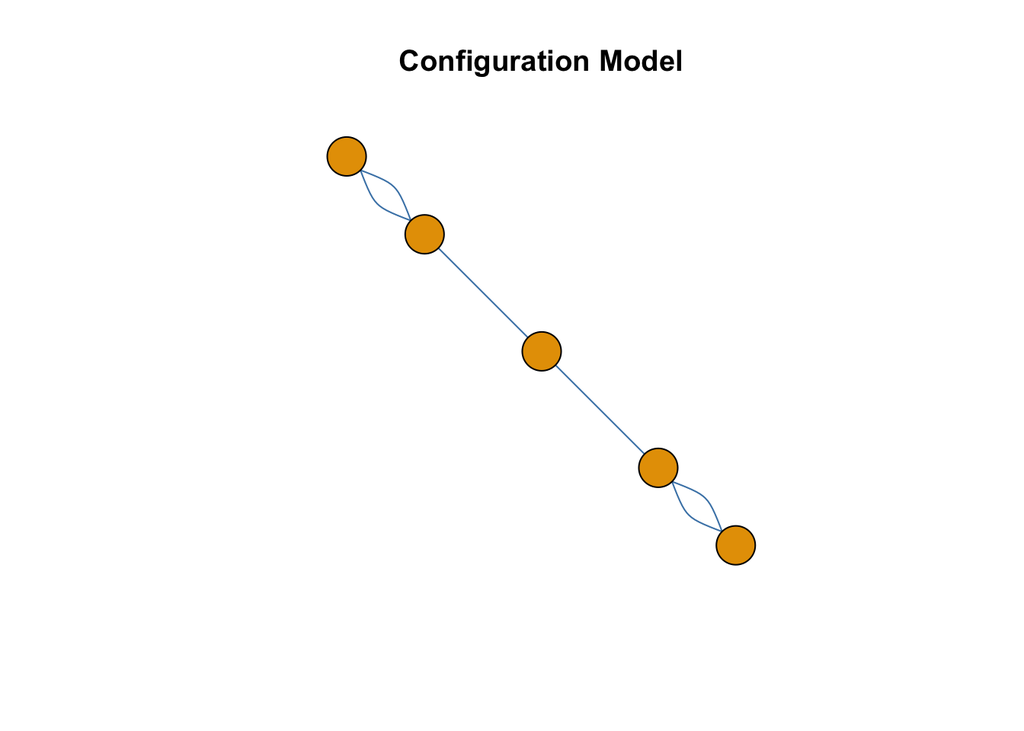

```r
g_conf <- igraph::sample_degseq(c(3,3,2,2,2))
plot(g_conf, main = "Configuration Model", vertex.size = 20, vertex.label = NA, edge.color = "steelblue")
```

### Small-world (Watts–Strogatz)

Starts with a regular lattice and randomly rewires edges with probability p. Produces networks with high clustering and short path lengths.

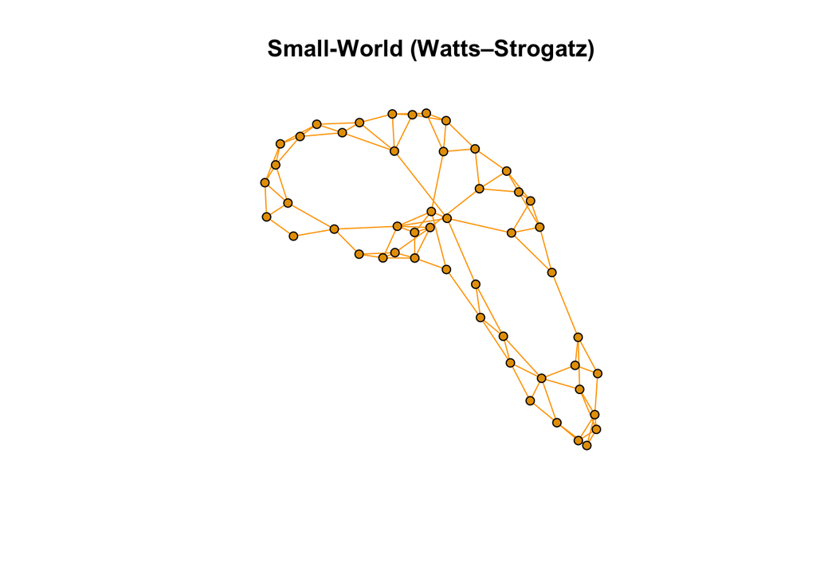

```r
g_ws <- sample_smallworld(dim = 1, size = 50, nei = 2, p = 0.1)
plot(g_ws, main = "Small-World (Watts–Strogatz)", vertex.size = 5, vertex.label = NA, edge.color = "orange")
```

### Scale-free (preferential attachment)

Nodes are added one by one, preferentially attaching to high-degree nodes. Produces networks with hubs and a power-law degree distribution.

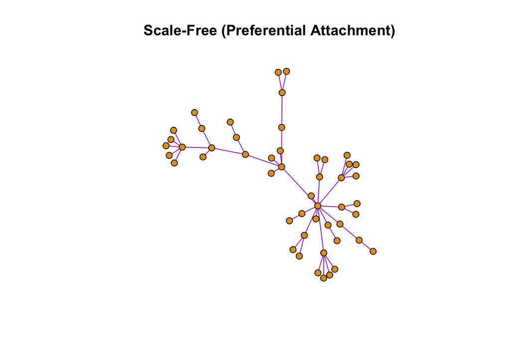

```r
g_sf <- sample_pa(n = 50, power = 1, directed = FALSE)
plot(g_sf, main = "Scale-Free (Preferential Attachment)", vertex.size = 6, vertex.label = NA, edge.color = "purple")
```